# Prediction Assignment Writeup

Ante Brozovic

In this assignment we will be using data from Weight Lifting Exercises Dataset. This dataset includes data from six young health participants that were asked to perform one set of 10 repetitions of the Unilateral Dumbbell Biceps Curl in five different fashions: exactly according to the specification (Class A), throwing the elbows to the front (Class B), lifting the dumbbell only halfway (Class C), lowering the dumbbell only halfway (Class D) and throwing the hips to the front (Class E). Class A corresponds to the specified execution of the exercise, while the other 4 classes correspond to common mistakes. Each participant had sensors attached to its arm, forearm, belt and dumbbell. We will use this sensor data to predict wich type of biceps curl participant performed. Dataset comes in csv format already split to training and testing part. So lets assign this datasets to data frames.

```r
training=read.csv('https://d396qusza40orc.cloudfront.net/predmachlearn/pml-training.csv',na.strings = c("NA",""))
testing=read.csv('https://d396qusza40orc.cloudfront.net/predmachlearn/pml-testing.csv',na.strings = c("NA",""))
```

Now we inspect dimensions of our data frames.

```r
dim(training);dim(testing)
```

```
## [1] 19622   160
```

```
## [1]  20 160
```

There is only 20 observations in testing set and 19622 cases in training set. Both sets are comprised of 160 variables. Lets take a glimpse at a first few.

```r
head(training[,1:15])
```

```
##   X user_name raw_timestamp_part_1 raw_timestamp_part_2   cvtd_timestamp
## 1 1  carlitos           1323084231               788290 05/12/2011 11:23
## 2 2  carlitos           1323084231               808298 05/12/2011 11:23
## 3 3  carlitos           1323084231               820366 05/12/2011 11:23
## 4 4  carlitos           1323084232               120339 05/12/2011 11:23
## 5 5  carlitos           1323084232               196328 05/12/2011 11:23
## 6 6  carlitos           1323084232               304277 05/12/2011 11:23
##   new_window num_window roll_belt pitch_belt yaw_belt total_accel_belt
## 1         no         11      1.41       8.07    -94.4                3
## 2         no         11      1.41       8.07    -94.4                3
## 3         no         11      1.42       8.07    -94.4                3
## 4         no         12      1.48       8.05    -94.4                3
## 5         no         12      1.48       8.07    -94.4                3
## 6         no         12      1.45       8.06    -94.4                3
##   kurtosis_roll_belt kurtosis_picth_belt kurtosis_yaw_belt skewness_roll_belt
## 1               <NA>                <NA>              <NA>               <NA>
## 2               <NA>                <NA>              <NA>               <NA>
## 3               <NA>                <NA>              <NA>               <NA>
## 4               <NA>                <NA>              <NA>               <NA>
## 5               <NA>                <NA>              <NA>               <NA>
## 6               <NA>                <NA>              <NA>               <NA>
```

There is no class variable in a first few. Lets try last columns.

```r
head(training[,155:160])
```

```
##   accel_forearm_y accel_forearm_z magnet_forearm_x magnet_forearm_y
## 1             203            -215              -17              654
## 2             203            -216              -18              661
## 3             204            -213              -18              658
## 4             206            -214              -16              658
## 5             206            -214              -17              655
## 6             203            -215               -9              660
##   magnet_forearm_z classe
## 1              476      A
## 2              473      A
## 3              469      A
## 4              469      A
## 5              473      A
## 6              478      A
```

The last column contains type of biceps curl participant performed in a given observation. It is named ‘classe’. This will be our response variable for classification.

So the first few variables are the participant name, timestamps and window variables. We don’t expect much of a prediction value from these and we will remove it from a training set. Also there are quite a few variables with NAs, reportedly variables that start with ‘kurtosis’, ‘skewness’ etc. These variables have valid values only if a value of ‘new_window’ column is ‘yes’. Since this occurence is rare in a dataset, we will also remove this variables from training data.

```r
training=training[,-c(1:7)];training=training[,colSums(is.na(training)) == 0]
dim(training)
```

```
## [1] 19622    53
```

We do the same with testing dataset.

```r
testing=testing[,-c(1:7)];testing=testing[,colSums(is.na(testing)) == 0]
dim(testing)
```

```
## [1] 20 53
```

So now we deal with 52 sensor predictors and 1 response that have 5 classes (A-E). Here we see frequencies for each class.

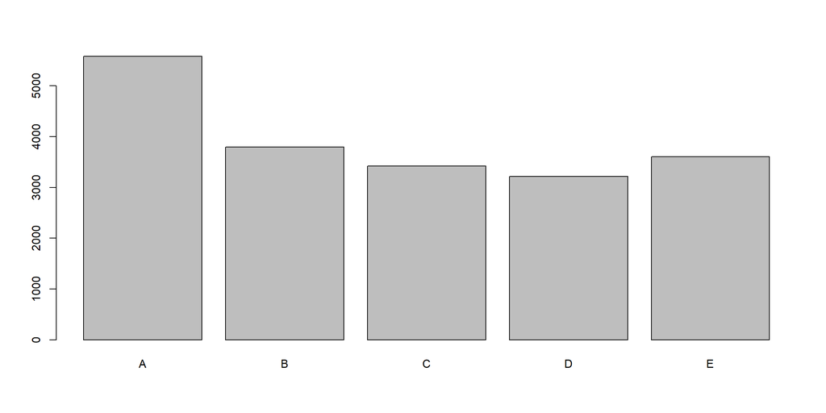

```r
plot(training$classe)
```

Now, lets load caret library and try to build some prediction models. We will train our models with 10-fold cross-validation. First classification method that comes into mind is a logistic regression, but we can’t use it here because our response has more than 2 class. We will build linear discriminant analysis model instead.

```r
library(caret)
set.seed(1234)
control=trainControl(method = 'cv', number = 10)
fit.lda=train(classe~.,data = training,trControl=control,method='lda')
fit.lda
```

```
## Linear Discriminant Analysis
##
## 19622 samples
##    52 predictor
##     5 classes: 'A', 'B', 'C', 'D', 'E'
##
## No pre-processing
## Resampling: Cross-Validated (10 fold)
## Summary of sample sizes: 17661, 17659, 17659, 17660, 17659, 17659, ...
## Resampling results:
##
##   Accuracy   Kappa
##   0.7021197  0.6230449
```

So accuracy of 0.7 doesn’t sound promising for a new data where class is unknown. Next, we will try non-parametric approach with k-nearest neighbors.

```r
fit.knn=train(classe~.,data = training,trControl=control,method='knn')
fit.knn
```

```
## k-Nearest Neighbors
##
## 19622 samples
##    52 predictor
##     5 classes: 'A', 'B', 'C', 'D', 'E'
##
## No pre-processing
## Resampling: Cross-Validated (10 fold)
## Summary of sample sizes: 17659, 17659, 17659, 17659, 17660, 17661, ...
## Resampling results across tuning parameters:
##
##   k  Accuracy   Kappa
##   5  0.9309955  0.9126972
##   7  0.9128516  0.8897212
##   9  0.8953208  0.8675069
##
## Accuracy was used to select the optimal model using the largest value.
## The final value used for the model was k = 5.
```

It seems that 5-nearest neighbors model gives us accuracy of 0.93 for the training dataset, which is a great improvement over LDA. But we are not satisfied yet, because real world test error will surely be more than 7%. Now we will try ensemble tree method with random forest.

```r
fit.rf=train(classe~.,data = training,trControl=control,method='rf')
fit.rf
```

```
## Random Forest
##
## 19622 samples
##    52 predictor
##     5 classes: 'A', 'B', 'C', 'D', 'E'
##
## No pre-processing
## Resampling: Cross-Validated (10 fold)
## Summary of sample sizes: 17660, 17658, 17659, 17659, 17661, 17661, ...
## Resampling results across tuning parameters:
##
##   mtry  Accuracy   Kappa
##    2    0.9954133  0.9941979
##   27    0.9955151  0.9943267
##   52    0.9899603  0.9872993
##
## Accuracy was used to select the optimal model using the largest value.
## The final value used for the model was mtry = 27.
```

So it seems that random forest classifier gives us accuracy of 99.55% on our training set. We shall use this model on our testing dataset.

```r
pred.rf=predict(fit.rf,testing)
pred.rf
```

```
##  [1] B A B A A E D B A A B C B A E E A B B B
## Levels: A B C D E
```